# Covid Data Project

Ekimetrics

4/29/2020

Aaron of Py-Tips fame and I have decided to offer up a little project. We’re going to be taking a look at some COVID-19 data provided by Johns Hopkins and put together by Github which can be found here: https:/github.com/datasets/covid-19.

Ohhh github…well might as throw in a little git lesson here also.

Everyone spin up their cmd -

```
1. Navigate to where you'd like to store these files
    For me that's `cd "OneDrive - Ekimetrics\Documents\Non-Project Work"`
2. Make a new folder for the R file and data
    mkdir CovidProject
3. Navigate into that file
```

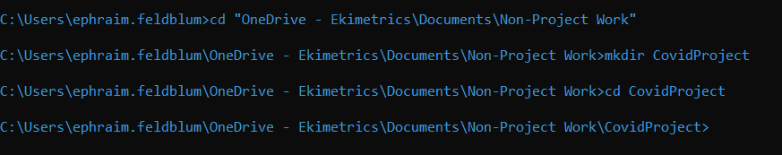

```
4. Open the github link and press the Green "Clone or Download" Button
5. In CMD type `git clone [insert link here from last step]
6. take a look at whats been downloaded
    Can just use `tree` here
7. Okay so what we probably want to do is move the data out to the main folder and then delete "covid-19" folder
    `move covid-19\data` # moves the data
    `RMDIR /Q/S covid-19` # Q = quiet mode, won't ask any questions, S = all files and folders within that
8. While you're at it:
    Make a new folder for your outputs: `mkdir outputs`
```

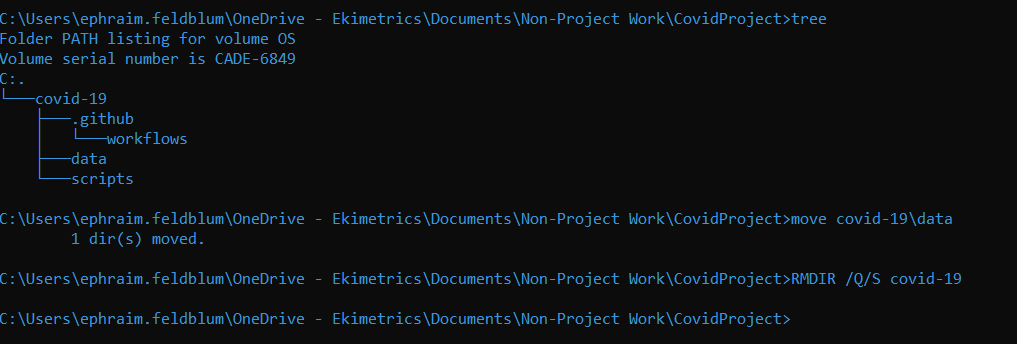

So all together thats: ps feel free to keep the other items, it allows you to look back in time of this data.

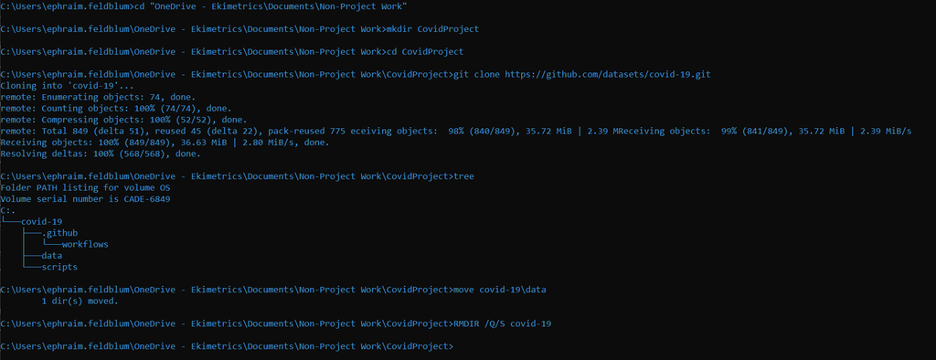

```r
library(tidyverse)
library(purrr)
library(stringr)
library(magrittr)
library(janitor)

library(zoo)
library(modelr)

library(gghighlight)
library(scales)

library(patchwork) # arrange plots
library(gt) # make some nicer looking tables


# Ref: https://5harad.com/mse125/r/visualization_code.html
addUnits <- function(n) {
  labels <- ifelse(n < 1000, n,  # less than thousands
                   ifelse(n < 1e6, paste0(round(n/1e3), 'k'),  # in thousands
                          ifelse(n < 1e9, paste0(round(n/1e6), 'M'),  # in millions
                                 ifelse(n < 1e12, paste0(round(n/1e9), 'B'), # in billions
                                        'too big!'
                                 ))))
  return(labels)
}

 scale_y_continuous(labels = addUnits)
```

```
## <ScaleContinuousPosition>
##  Range:
##  Limits:    0 --    1
```

```r
Eki_theme <- theme(panel.grid.minor = element_blank(),
                   panel.grid.major = element_blank(),
                   axis.ticks = element_blank(),
                   panel.background = element_rect(fill = "transparent",colour = NA),
                   plot.background = element_rect(fill = "transparent",colour = NA))
```

# What’s the point of this exercise?

I took as a chance to show off both what we have looked at so far and show off a few items coming in the next few weeks to show you how these small bits and bobs can be combined into something.

### Formatting:

I’m working on this document thinking it’s somewhere between exploration and being ready to show to somebody - aka I’ll put some time into making it look nice but not too much.

# Step 1: What do I have?

Okay, I’ve been given a folder of random data files. My plan is to try and take a peak at some of them but there first thing I need to decided is, “what is useful to me here?”

Sometimes you might know what you want to do already, but, currently, I’m flying blind - part of the beauty of R-tips.

```r
list.files("data")
```

```
## [1] "countries-aggregated.csv"          "key-countries-pivoted.csv"
## [3] "reference.csv"                     "time-series-19-covid-combined.csv"
## [5] "us_confirmed.csv"                  "us_deaths.csv"
## [7] "worldwide-aggregated.csv"
```

So, I’m not positive yet but I’m thinking I’ll focus in on the US.

```r
# so I split out all the US files
fileNames <- list.files("data")
usFilesLoc <- grep("us",fileNames) # selecting the indexes of the us files
usFiles <- fileNames[usFilesLoc]
otherFiles <- fileNames[-usFilesLoc]
```

All the files are csvs which is nice.

```r
# Im gonna check out the "other files" first
head(read_csv(paste0("data/",otherFiles[4])),25)
```

```
## # A tibble: 25 x 8
##    Date       `Country/Region` `Province/State`   Lat  Long Confirmed Recovered
##    <date>     <chr>            <chr>            <dbl> <dbl>     <dbl>     <dbl>
##  1 2020-01-22 Afghanistan      <NA>                33    65         0         0
##  2 2020-01-23 Afghanistan      <NA>                33    65         0         0
##  3 2020-01-24 Afghanistan      <NA>                33    65         0         0
##  4 2020-01-25 Afghanistan      <NA>                33    65         0         0
##  5 2020-01-26 Afghanistan      <NA>                33    65         0         0
##  6 2020-01-27 Afghanistan      <NA>                33    65         0         0
##  7 2020-01-28 Afghanistan      <NA>                33    65         0         0
##  8 2020-01-29 Afghanistan      <NA>                33    65         0         0
##  9 2020-01-30 Afghanistan      <NA>                33    65         0         0
## 10 2020-01-31 Afghanistan      <NA>                33    65         0         0
## # … with 15 more rows, and 1 more variable: Deaths <dbl>
```

```r
otherFilesGuide <- tribble( ~file, ~contains,
         otherFiles[1],"Overall Countries with Confirmed, Recovered, and Deaths",
         otherFiles[2], "pivoted deaths for US, UK, Italy, France, Germ, Spa, Iran",
         otherFiles[3], "Countries with codes, lat&lon, population",
         otherFiles[4], "Countries with confirmed, recovered, deaths - same as 1 with province/state",
         otherFiles[5], "worldwide total confirmed, recovered, deaths, increase rate"
         )
```

I did the above manually in R and took a few moments to check out each DF.

## US Data:

```r
# Because I think I'm going to focus on the US let's load all those files in

us_confirmed <- read_csv(paste0("data/", usFiles[1]))
us_deaths <- read_csv(paste0("data/", usFiles[2]))
us_confirmed %>%
  head() %>%
  gt %>%
  tab_header(
    title = md("Confirmed US Cases"),subtitle = md("&nbsp;"))
```

Confirmed US Cases

| UID | iso2 | iso3 | code3 | FIPS | Admin2 | Lat | Combined_Key | Date | Case | Long | Country/Region | Province/State |
| --- | --- | --- | --- | --- | --- | --- | --- | --- | --- | --- | --- | --- |
| 16 | AS | ASM | 16 | 60 | NA | -14.271 | American Samoa, US | 2020-01-22 | 0 | -170.132 | US | American Samoa |
| 16 | AS | ASM | 16 | 60 | NA | -14.271 | American Samoa, US | 2020-01-23 | 0 | -170.132 | US | American Samoa |
| 16 | AS | ASM | 16 | 60 | NA | -14.271 | American Samoa, US | 2020-01-24 | 0 | -170.132 | US | American Samoa |
| 16 | AS | ASM | 16 | 60 | NA | -14.271 | American Samoa, US | 2020-01-25 | 0 | -170.132 | US | American Samoa |
| 16 | AS | ASM | 16 | 60 | NA | -14.271 | American Samoa, US | 2020-01-26 | 0 | -170.132 | US | American Samoa |
| 16 | AS | ASM | 16 | 60 | NA | -14.271 | American Samoa, US | 2020-01-27 | 0 | -170.132 | US | American Samoa |

```r
us_deaths %>%
  head()%>%
  gt %>%
  tab_header(
    title = md("Confirmed US Deaths"),subtitle = md("&nbsp;"))
```

Confirmed US Deaths

| UID | iso2 | iso3 | code3 | FIPS | Admin2 | Lat | Combined_Key | Population | Date | Case | Long | Country/Region | Province/State |
| --- | --- | --- | --- | --- | --- | --- | --- | --- | --- | --- | --- | --- | --- |
| 16 | AS | ASM | 16 | 60 | NA | -14.271 | American Samoa, US | 55641 | 2020-01-22 | 0 | -170.132 | US | American Samoa |
| 16 | AS | ASM | 16 | 60 | NA | -14.271 | American Samoa, US | 55641 | 2020-01-23 | 0 | -170.132 | US | American Samoa |
| 16 | AS | ASM | 16 | 60 | NA | -14.271 | American Samoa, US | 55641 | 2020-01-24 | 0 | -170.132 | US | American Samoa |
| 16 | AS | ASM | 16 | 60 | NA | -14.271 | American Samoa, US | 55641 | 2020-01-25 | 0 | -170.132 | US | American Samoa |
| 16 | AS | ASM | 16 | 60 | NA | -14.271 | American Samoa, US | 55641 | 2020-01-26 | 0 | -170.132 | US | American Samoa |
| 16 | AS | ASM | 16 | 60 | NA | -14.271 | American Samoa, US | 55641 | 2020-01-27 | 0 | -170.132 | US | American Samoa |

So one of my first questions here is whether I can just merger these two dfs together? They seem pretty identical. Some quick checks:

```r
ncol(us_confirmed) == ncol(us_deaths) # oo so they already don't have the same number of columns
```

```
## [1] FALSE
```

```r
ncol(us_confirmed) > ncol(us_deaths) # us_deaths have more
```

```
## [1] FALSE
```

```r
setdiff(colnames(us_deaths),colnames(us_confirmed)) #so no population in confirmed
```

```
## [1] "Population"
```

```r
setdiff(colnames(us_confirmed),colnames(us_deaths)) # no differences
```

```
## character(0)
```

```r
colnames(us_deaths)
```

```
##  [1] "UID"            "iso2"           "iso3"           "code3"
##  [5] "FIPS"           "Admin2"         "Lat"            "Combined_Key"
##  [9] "Population"     "Date"           "Case"           "Long"
## [13] "Country/Region" "Province/State"
```

```r
nrow(us_confirmed) == nrow(us_deaths) # same number of rows - makes sense, certain # days for certain # of places
```

```
## [1] TRUE
```

Okay, I think we’re pretty ready to just go ahead and rename the values column. And merge the two files.

```r
us_confirmed <- dplyr::rename(us_confirmed, confirmed = Case)
us_deaths <- dplyr::rename(us_deaths, deaths = Case)

us_data <- us_confirmed %>%
    full_join(us_deaths)%>%
    pivot_longer(c(deaths, confirmed), names_to = "confirm/deaths", values_to = "cumValues")%>%
    clean_names()
```

Let’s do some checks on the US data - our primary source:

```r
library(plyr) # Im putting this here bc plyr annoys me so Im going to be unloading it at the end of this chunk
# any missing values?

ldply(us_data,function(x)  # this function:
    sum(is.na(x)) / nrow(us_data))%>%
    dplyr::rename(Variable = `.id`, `Percent Missing` = V1)%>%
  arrange(desc(`Percent Missing`))%>%
  gt()%>%
  fmt_percent(
    columns = vars(`Percent Missing`),
    decimals =3)
```

| Variable | Percent Missing |
| --- | --- |
| fips | 0.307% |
| admin2 | 0.215% |
| uid | 0.031% |
| lat | 0.031% |
| long | 0.031% |
| iso2 | 0.000% |
| iso3 | 0.000% |
| code3 | 0.000% |
| combined_key | 0.000% |
| date | 0.000% |
| country_region | 0.000% |
| province_state | 0.000% |
| population | 0.000% |
| confirm_deaths | 0.000% |
| cum_values | 0.000% |

```r
detach(package:plyr, unload=TRUE)
```

Let’s take a peak at those admin areas we’re missing:

```r
us_data %>%
    filter(is.na(admin2))%>%
    distinct(province_state)
```

```
## # A tibble: 7 x 1
##   province_state
##   <chr>
## 1 American Samoa
## 2 Guam
## 3 Northern Mariana Islands
## 4 Puerto Rico
## 5 Virgin Islands
## 6 Diamond Princess
## 7 Grand Princess
```

Alright, every place we’re missing more granular data makes sense…well let’s see what areas we’re covering with this data set.

```r
# How many areas are we counting
us_data %>% distinct(province_state) # so all the states + dc + some other US stuff (sorry Gman) + two cruise ships
```

```
## # A tibble: 58 x 1
##    province_state
##    <chr>
##  1 American Samoa
##  2 Guam
##  3 Northern Mariana Islands
##  4 Puerto Rico
##  5 Virgin Islands
##  6 Alabama
##  7 Alaska
##  8 Arizona
##  9 Arkansas
## 10 California
## # … with 48 more rows
```

```r
us_data %>% distinct(admin2) # okay so we have 1903 localities
```

```
## # A tibble: 1,903 x 1
##    admin2
##    <chr>
##  1 <NA>
##  2 Autauga
##  3 Baldwin
##  4 Barbour
##  5 Bibb
##  6 Blount
##  7 Bullock
##  8 Butler
##  9 Calhoun
## 10 Chambers
## # … with 1,893 more rows
```

Let’s take a look at the amount of localities per state

```r
us_data %>%
    distinct(admin2, .keep_all = TRUE)%>%
    select(admin2, province_state) %$%
    table(province_state)%>%
    as.data.frame.table()%>%
    arrange(-Freq) %>%
  head(15)%>%
  gt() %>%
  tab_header(
    title = md("Localities Per State for 15 most Divided"),subtitle = md("&nbsp;"))
```

Localities Per State for 15 most Divided

| province_state | Freq |
| --- | --- |
| Texas | 161 |
| Georgia | 109 |
| Virginia | 73 |
| Alabama | 69 |
| Kansas | 68 |
| Michigan | 65 |
| North Carolina | 65 |
| Minnesota | 62 |
| Arkansas | 58 |
| California | 57 |
| Colorado | 56 |
| Kentucky | 56 |
| Illinois | 55 |
| Florida | 50 |
| Louisiana | 48 |

Let’s figure out what the max day, as the numbers are cumulative it will be pretty useful to save that date as a variable instead of tons of ctrl-c, ctrl-v.

```r
maxDate <- max(us_data$date)
```

It’s 2020-04-28 and as of writing this it’s the evening of April 29th so this is probably a good idea because by the time you run this code (or I rerun to send to you), the date will be different… and I made this document reactive so maybe the first part of this sentence won’t even say April 28th….

Might as well also see the min date:

```r
min(us_data$date)
```

```
## [1] "2020-01-22"
```

## Some Graphs

Alright let’s maybe take a look at some graphs to try and start to get a handle on this data.

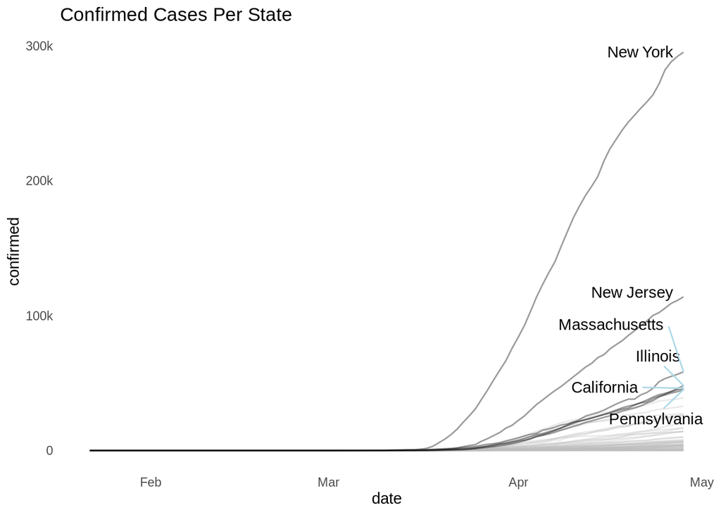

```r
us_data %>%
  filter(confirm_deaths == "confirmed")%>%
  group_by(date, province_state)%>%
  summarise(confirmed = sum(cum_values)) %>%
ggplot(aes(date,confirmed, group = province_state)) +
    geom_line(alpha = 1/3)+
    gghighlight(max(confirmed) > 40000,
            label_params = list(
                fill = NA,
                segment.color = "light blue",
                label.size = NA
            )) +
    scale_y_continuous(labels = addUnits) +
  Eki_theme +
  ggtitle("Confirmed Cases Per State")
```

Let’s split NYC - as we should cuz it be the home.

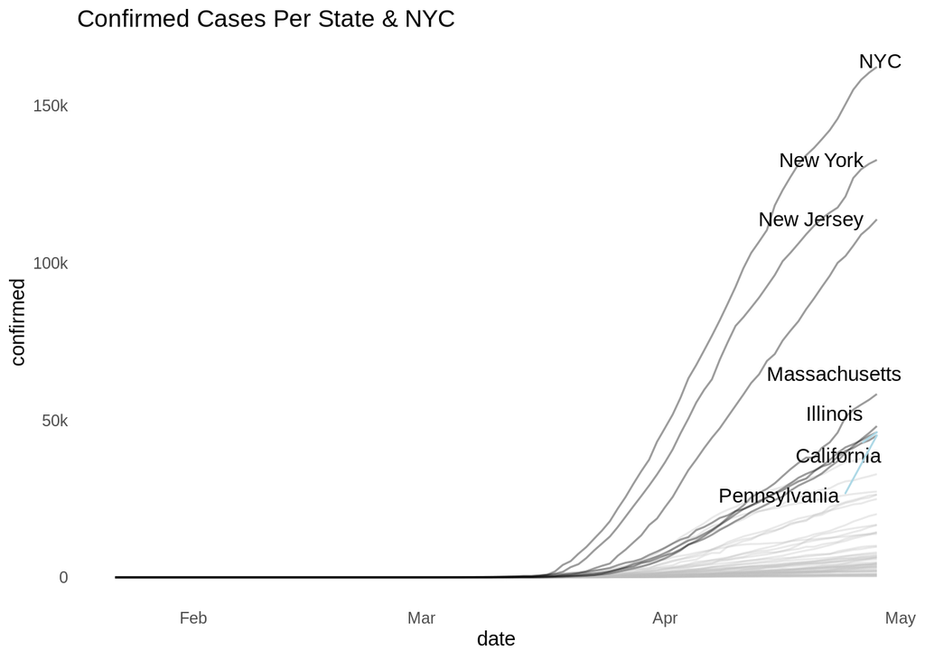

```r
us_data %>%
  filter(confirm_deaths == "confirmed")%>%
  mutate(province_state = ifelse(admin2 == "New York", "NYC", province_state)) %>%
  group_by(date, province_state)%>%
  summarise(confirmed = sum(cum_values)) %>%
ggplot(aes(date,confirmed, group = province_state)) +
    geom_line(alpha = 1/3)+
    gghighlight(max(confirmed) > 40000,
            label_params = list(
                fill = NA,
                segment.color = "light blue",
                label.size = NA
            )) +
    scale_y_continuous(labels = addUnits)+
  Eki_theme +
  ggtitle("Confirmed Cases Per State & NYC")
```

Maybe we should also take a peak at what’s going on inside our own state?

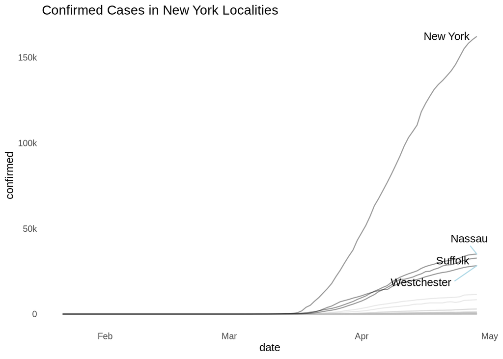

```r
us_data %>%
  filter(confirm_deaths == "confirmed",
         province_state == "New York")%>%
  mutate(province_state = ifelse(admin2 == "New York", "NYC", province_state)) %>%
  group_by(date, province_state,admin2)%>%
  summarise(confirmed = sum(cum_values)) %>%
ggplot(aes(date,confirmed, group = admin2)) +
    geom_line(alpha = 1/3)+
    gghighlight(max(confirmed) > 15000,
            label_params = list(
                fill = NA,
                segment.color = "light blue",
                label.size = NA
            )) +
    scale_y_continuous(labels = addUnits)+
  Eki_theme +
  ggtitle("Confirmed Cases in New York Localities")
```

## Let’s zoom in on NYC

Let’s get daily additions

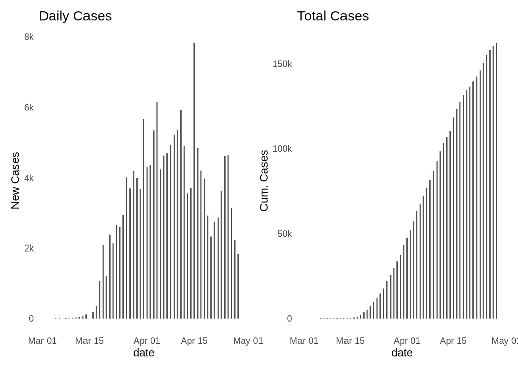

```r
foo <- us_data %>%
  filter(admin2 ==  "New York",
         date > "2020-03-01")%>%
  group_by(confirm_deaths,admin2)%>%
  mutate(daily_vals = cum_values - lag(cum_values))

dailyConfirmed_nyc_plot <- foo %>%
  filter(confirm_deaths == "confirmed") %>%
ggplot(aes(y = daily_vals, x = date)) +
  geom_col(width = .4) +
  Eki_theme+
  scale_y_continuous(labels = addUnits)+
  ggtitle("Daily Cases")+
  ylab("New Cases")

totalConfirmed_nyc_plot <- foo %>%
  filter(confirm_deaths == "confirmed") %>%
ggplot(aes(y = cum_values, x = date)) +
  geom_col(width = .4) +
  Eki_theme+
  scale_y_continuous(labels = addUnits)+
  ggtitle("Total Cases")+
  ylab("Cum. Cases")

dailyConfirmed_nyc_plot + totalConfirmed_nyc_plot
```

alright, maybe let’s take a look at the left chart on a 3 day rolling average:

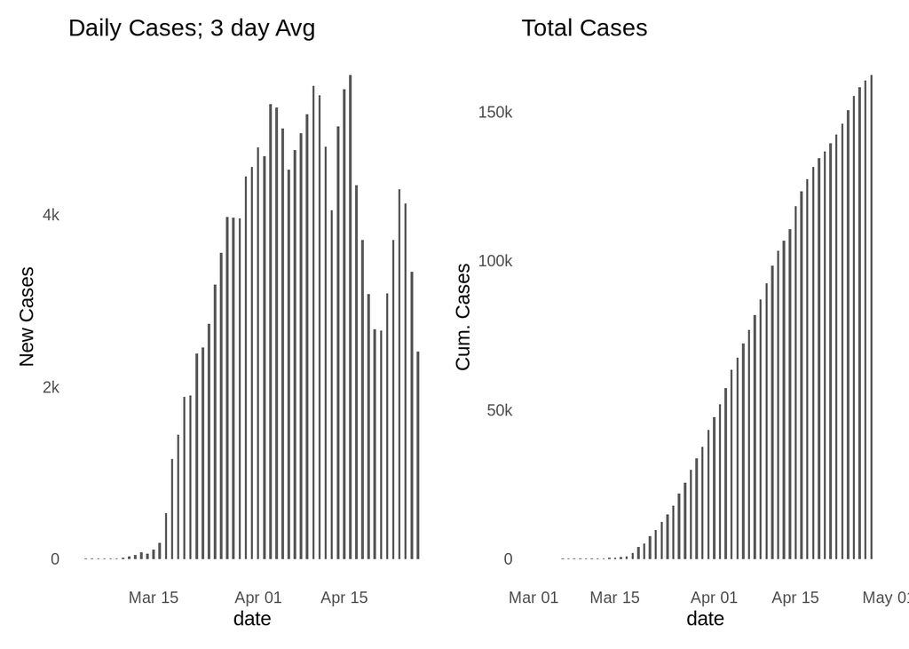

```r
dailyConfirmed_nyc_plot_3dayavg <- foo %>%
  filter(confirm_deaths == "confirmed") %>%
 mutate(daily_vals3=rollapply(daily_vals,3,mean,fill=NA)) %>%
ggplot(aes(y = daily_vals3, x = date)) +
  geom_col(width = .4) +
  Eki_theme+
  scale_y_continuous(labels = addUnits) +
  ggtitle("Daily Cases; 3 day Avg")+
  ylab("New Cases")

dailyConfirmed_nyc_plot_3dayavg + totalConfirmed_nyc_plot
```

And for deaths, unfortunately.

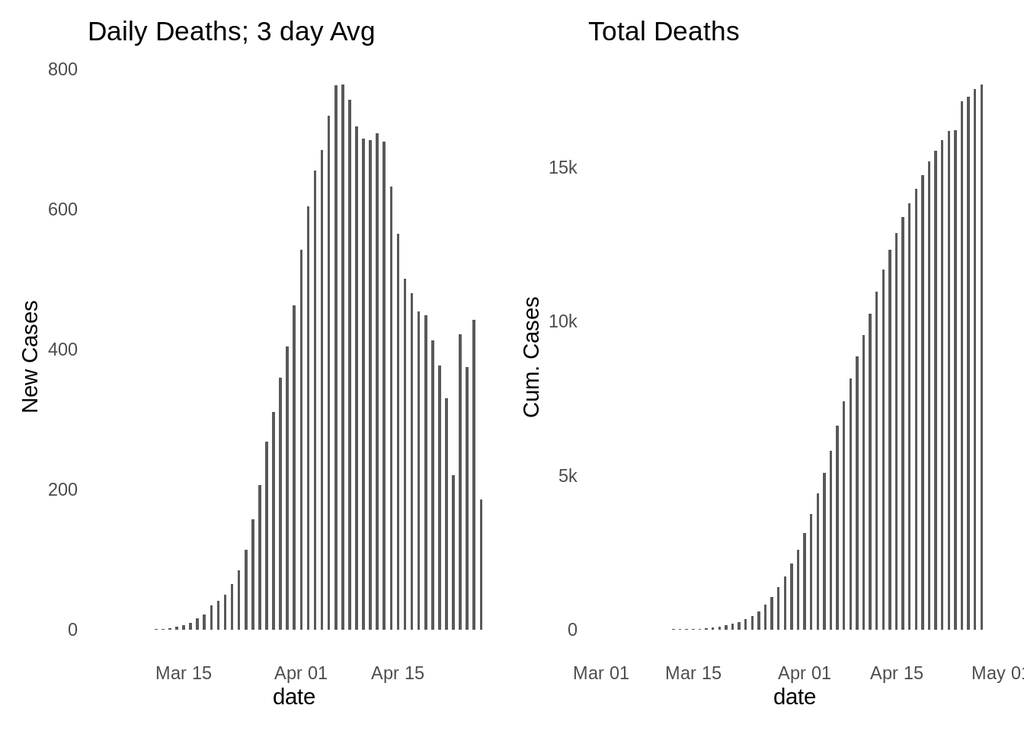

```r
dailyDeaths_nyc_plot_3dayavg <- foo %>%
  filter(confirm_deaths == "deaths") %>%
 mutate(daily_vals3=rollapply(daily_vals,3,mean,fill=NA)) %>%
ggplot(aes(y = daily_vals3, x = date)) +
  geom_col(width = .4) +
  Eki_theme+
  scale_y_continuous(labels = addUnits) +
  ggtitle("Daily Deaths; 3 day Avg")+
  ylab("New Cases")

totalDeaths_nyc_plot <- foo %>%
  filter(confirm_deaths == "deaths") %>%
ggplot(aes(y = cum_values, x = date)) +
  geom_col(width = .4)+
  Eki_theme+
  scale_y_continuous(labels = addUnits) +
  ggtitle("Total Deaths")+
  ylab("Cum. Cases")

dailyDeaths_nyc_plot_3dayavg + totalDeaths_nyc_plot
```

## Let’s try something fun

So, yes, I understand this isn’t the best “use case” for this but I don’t care I’m having fun.

```r
us_data <- us_data %>%
  mutate(combined_key= gsub(", US","",combined_key))
```

```r
all_locals <- us_data %>%
filter(confirm_deaths == "confirmed") %>%

  ggplot(aes(date, cum_values, group = combined_key)) +
    geom_line(alpha = 1/3) +
  gghighlight(max(cum_values) > 20000,
            label_params = list(
                fill = NA,
                segment.color = "light blue",
                label.size = NA
            )) +
  scale_y_continuous(labels = addUnits)+
  Eki_theme +
  ggtitle("Confirmed Cases all Localities")
```

```
## label_key: combined_key
```

```r
all_locals_subNYC <- us_data %>%
filter(confirm_deaths == "confirmed",
       combined_key != "New York City, New York") %>%

  ggplot(aes(date, cum_values, group = combined_key)) +
    geom_line(alpha = 1/3) +
  gghighlight(max(cum_values) > 12000,
            label_params = list(
                fill = NA,
                segment.color = "light blue",
                label.size = NA,
                size =2
            ))  +
  scale_y_continuous(labels = addUnits)+
  Eki_theme +
  ggtitle("Confirmed Cases all Localities Sub NYC")
```

```
## label_key: combined_key
```

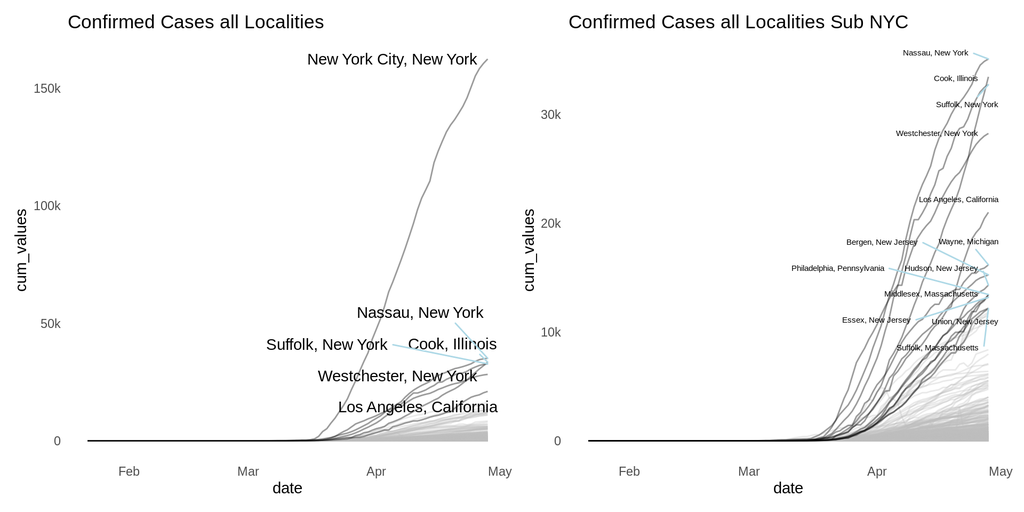

```r
all_locals + all_locals_subNYC
```

So let’s try and fit a small model for deaths based off of days and confirmed cases:

```r
Suffolk_data <- us_data %>%
    filter(combined_key == "Suffolk, New York",
           date >= "2020-03-01")%>%
    pivot_wider(names_from = confirm_deaths, values_from = cum_values)%>%
      group_by(combined_key)%>%
    mutate(
        daily_deaths = deaths - lag(deaths),
        daily_deaths3=rollapply(daily_deaths,3,mean,fill=0),

        daily_confirmed = confirmed - lag(confirmed),
        daily_confirmed3=rollapply(daily_confirmed,3,mean,fill=0))%>%
    replace_na(list(daily_deaths3 = 0, daily_confirmed3 = 0, daily_deaths =0, daily_confirmed = 0))
```

So, Let’s fit a model to one of the localities and see how things look.

```r
suf_mod <- lm(daily_deaths3 ~ daily_confirmed3 + date, data = Suffolk_data)
```

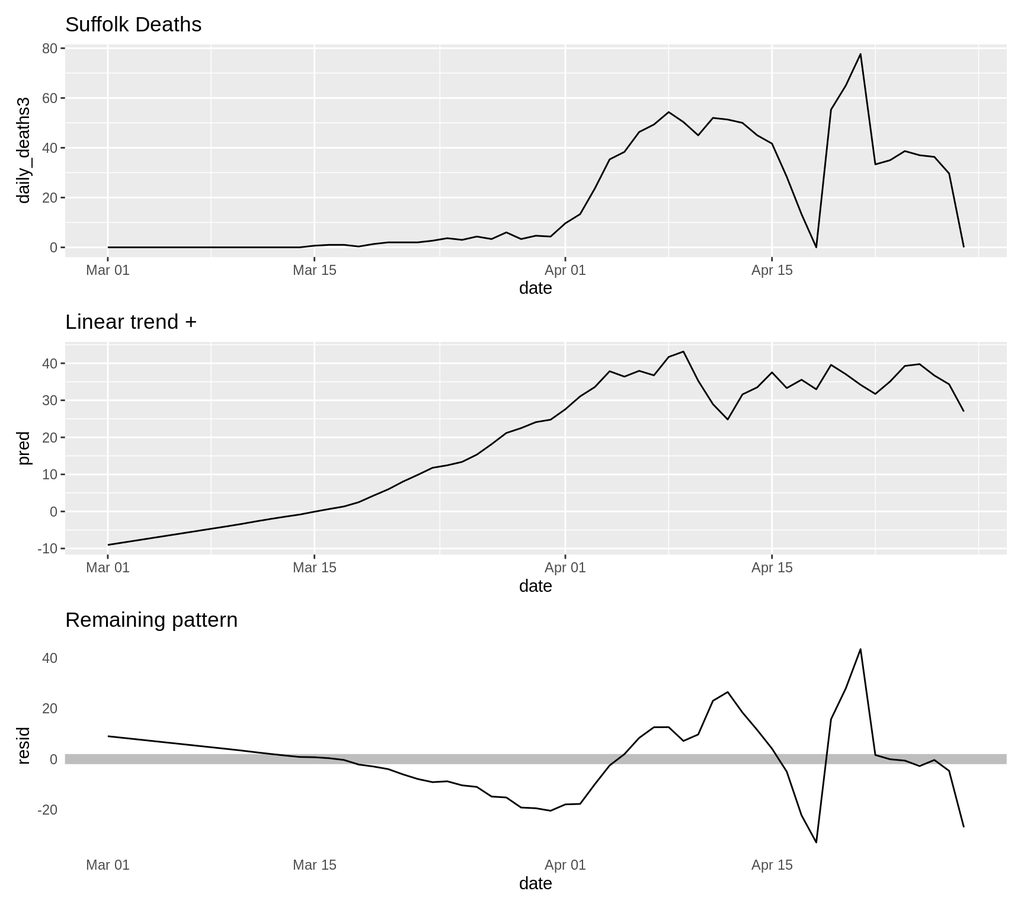

```r
Pure_data <- Suffolk_data %>%
    ggplot(aes(date, daily_deaths3))+
    geom_line()+
    ggtitle("Suffolk Deaths")

LinTrendPlot <- Suffolk_data %>%
  add_predictions(suf_mod) %>%
  ggplot(aes(date, pred)) +
  geom_line() +
  ggtitle("Linear trend + ")

residLine <- Suffolk_data %>%
  add_residuals(suf_mod) %>%
  ggplot(aes(date, resid)) +
  geom_hline(yintercept = 0, colour = "grey", size = 3) +
  geom_line() +
  ggtitle("Remaining pattern")+
    Eki_theme

Pure_data / LinTrendPlot / residLine
```

So let’s group our data into a nested dataframe so we can fit a model on every locality.

```r
us_step1 <- us_data %>%
    select(admin2, combined_key, date, province_state, population,
           confirm_deaths, cum_values)%>%
    pivot_wider(names_from = confirm_deaths, values_from = cum_values)%>%     group_by(combined_key)%>%
    mutate(
        daily_deaths = deaths - lag(deaths),
        daily_deaths3=rollapply(daily_deaths,3,mean,fill=0),

        daily_confirmed = confirmed - lag(confirmed),
        daily_confirmed3=rollapply(daily_confirmed,3,mean,fill=0))%>%
    replace_na(list(daily_deaths3 = 0, daily_confirmed3 = 0, daily_deaths =0, daily_confirmed = 0))

byLocality <- us_step1 %>%
    group_by(combined_key) %>%
    nest()

byLocality
```

```
## # A tibble: 3,262 x 2
## # Groups:   combined_key [3,262]
##    combined_key             data
##    <chr>                    <list>
##  1 American Samoa           <tibble [98 × 10]>
##  2 Guam                     <tibble [98 × 10]>
##  3 Northern Mariana Islands <tibble [98 × 10]>
##  4 Puerto Rico              <tibble [98 × 10]>
##  5 Virgin Islands           <tibble [98 × 10]>
##  6 Autauga, Alabama         <tibble [98 × 10]>
##  7 Baldwin, Alabama         <tibble [98 × 10]>
##  8 Barbour, Alabama         <tibble [98 × 10]>
##  9 Bibb, Alabama            <tibble [98 × 10]>
## 10 Blount, Alabama          <tibble [98 × 10]>
## # … with 3,252 more rows
```

It’s not very easy to look into this on an aggregate scale - but you can still peek.

```r
byLocality$data[[5]]
```

```
## # A tibble: 98 x 10
##    admin2 date       province_state population deaths confirmed daily_deaths
##    <chr>  <date>     <chr>               <dbl>  <dbl>     <dbl>        <dbl>
##  1 <NA>   2020-01-22 Virgin Islands     107268      0         0            0
##  2 <NA>   2020-01-23 Virgin Islands     107268      0         0            0
##  3 <NA>   2020-01-24 Virgin Islands     107268      0         0            0
##  4 <NA>   2020-01-25 Virgin Islands     107268      0         0            0
##  5 <NA>   2020-01-26 Virgin Islands     107268      0         0            0
##  6 <NA>   2020-01-27 Virgin Islands     107268      0         0            0
##  7 <NA>   2020-01-28 Virgin Islands     107268      0         0            0
##  8 <NA>   2020-01-29 Virgin Islands     107268      0         0            0
##  9 <NA>   2020-01-30 Virgin Islands     107268      0         0            0
## 10 <NA>   2020-01-31 Virgin Islands     107268      0         0            0
## # … with 88 more rows, and 3 more variables: daily_deaths3 <dbl>,
## #   daily_confirmed <dbl>, daily_confirmed3 <dbl>
```

Alright, so now we have the data ready for this test, let’s get our tools to actually perform it ready.

```r
local_model <- function(df) {
    lm(daily_deaths3 ~ daily_confirmed3 + date, data = df)
}
```

The dataframes are in a list so we can use purrr’s map() to apply our function to each element. Purrr is kind of a scary package for me tbh.

```r
byLocality <- byLocality %>%
    mutate(model = map(data, local_model))
```

We did it this way to keep the results and data tied together and avoid errors.

```r
byLocality
```

```
## # A tibble: 3,262 x 3
## # Groups:   combined_key [3,262]
##    combined_key             data               model
##    <chr>                    <list>             <list>
##  1 American Samoa           <tibble [98 × 10]> <lm>
##  2 Guam                     <tibble [98 × 10]> <lm>
##  3 Northern Mariana Islands <tibble [98 × 10]> <lm>
##  4 Puerto Rico              <tibble [98 × 10]> <lm>
##  5 Virgin Islands           <tibble [98 × 10]> <lm>
##  6 Autauga, Alabama         <tibble [98 × 10]> <lm>
##  7 Baldwin, Alabama         <tibble [98 × 10]> <lm>
##  8 Barbour, Alabama         <tibble [98 × 10]> <lm>
##  9 Bibb, Alabama            <tibble [98 × 10]> <lm>
## 10 Blount, Alabama          <tibble [98 × 10]> <lm>
## # … with 3,252 more rows
```

Add residuals

```r
byLocality <- byLocality %>%
  mutate(
    resids = map2(data, model, add_residuals)
  )
```

Unnest stem.

```r
resids <- unnest(byLocality, resids)
```

```r
resids
```

```
## # A tibble: 319,676 x 14
## # Groups:   combined_key [3,262]
##    combined_key data  model admin2 date       province_state population deaths
##    <chr>        <lis> <lis> <chr>  <date>     <chr>               <dbl>  <dbl>
##  1 American Sa… <tib… <lm>  <NA>   2020-01-22 American Samoa      55641      0
##  2 American Sa… <tib… <lm>  <NA>   2020-01-23 American Samoa      55641      0
##  3 American Sa… <tib… <lm>  <NA>   2020-01-24 American Samoa      55641      0
##  4 American Sa… <tib… <lm>  <NA>   2020-01-25 American Samoa      55641      0
##  5 American Sa… <tib… <lm>  <NA>   2020-01-26 American Samoa      55641      0
##  6 American Sa… <tib… <lm>  <NA>   2020-01-27 American Samoa      55641      0
##  7 American Sa… <tib… <lm>  <NA>   2020-01-28 American Samoa      55641      0
##  8 American Sa… <tib… <lm>  <NA>   2020-01-29 American Samoa      55641      0
##  9 American Sa… <tib… <lm>  <NA>   2020-01-30 American Samoa      55641      0
## 10 American Sa… <tib… <lm>  <NA>   2020-01-31 American Samoa      55641      0
## # … with 319,666 more rows, and 6 more variables: confirmed <dbl>,
## #   daily_deaths <dbl>, daily_deaths3 <dbl>, daily_confirmed <dbl>,
## #   daily_confirmed3 <dbl>, resid <dbl>
```

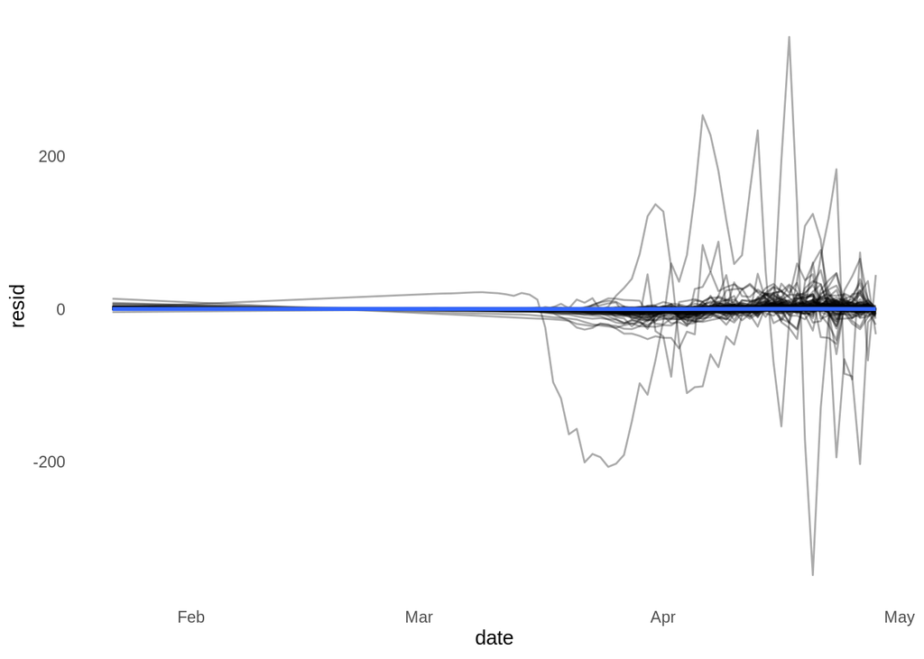

```r
residualPlot <- resids %>%
  ggplot(aes(date, resid)) +
    geom_line(aes(group = combined_key), alpha = 1 / 3) +
    geom_smooth(se = FALSE)+
    Eki_theme


residualPlot
```

```r
# build our categories - could do a join but I don't want to have to share additional data
northeast <- c("Connecticut", "Maine", "Massachusetts", "New Hampshire", "Rhode Island", "Vermont", "New Jersey", "New York", "Pennsylvania")

midwest <- c("Illinois", "Indiana", "Michigan", "Ohio", "Wisconsin", "Iowa", "Kansas", "Minnesota", "Missouri", "Nebraska", "North Dakota", "South Dakota")

south <- c("Delaware", "Florida", "Georgia", "Maryland", "North Carolina", "South Carolina", "Virginia", "District of Columbia", "West Virginia", "Alabama", "Kentucky", "Mississippi", "Tennessee", "Arkansas", "Louisiana", "Oklahoma", "Texas")

west <- c("Arizona", "Colorado", "Idaho", "Montana", "Nevada", "New Mexico", "Utah", "Wyoming", "Alaska", "California", "Hawaii", "Oregon", "Washington")

#add those regions

resids$region <- case_when(
    resids$province_state %in% northeast ~ "northeast",
    resids$province_state %in% midwest ~ "midwest",
    resids$province_state %in% south ~ "south",
    resids$province_state %in% west ~ "west",
    TRUE ~ "other"
)
```

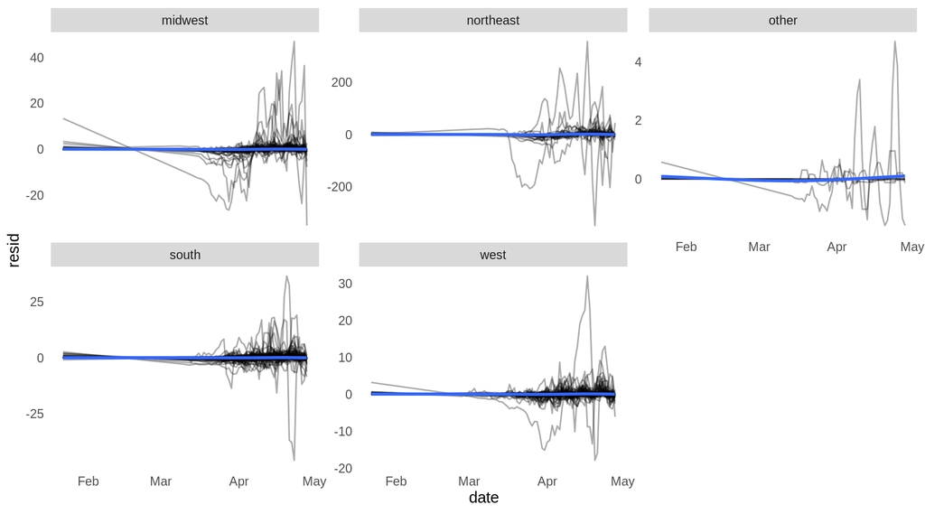

```r
 resids %>%
  ggplot(aes(date, resid)) +
    geom_line(aes(group = combined_key), alpha = 1 / 3) +
    geom_smooth(se = FALSE)+
    Eki_theme +
    facet_wrap(~region,
               scales = "free_y")
```

Dope, great models doing the worst in the most important area. Well if it was this easy….

```r
library(broom)
broom::glance(suf_mod)
```

```
## # A tibble: 1 x 11
##   r.squared adj.r.squared sigma statistic  p.value    df logLik   AIC   BIC
##       <dbl>         <dbl> <dbl>     <dbl>    <dbl> <int>  <dbl> <dbl> <dbl>
## 1     0.620         0.606  13.9      45.7 1.71e-12     3  -238.  483.  491.
## # … with 2 more variables: deviance <dbl>, df.residual <int>
```

```r
model_deets <- byLocality %>%
  mutate(glance = map(model, broom::glance)) %>%
  unnest(glance)
```

```
## Warning in stats::summary.lm(x): essentially perfect fit: summary may be
## unreliable
```

```r
model_deets
```

```
## # A tibble: 3,262 x 15
## # Groups:   combined_key [3,262]
##    combined_key data  model resids r.squared adj.r.squared  sigma statistic
##    <chr>        <lis> <lis> <list>     <dbl>         <dbl>  <dbl>     <dbl>
##  1 American Sa… <tib… <lm>  <tibb…   NaN          NaN      0         NaN
##  2 Guam         <tib… <lm>  <tibb…     0.333        0.319  0.121      23.8
##  3 Northern Ma… <tib… <lm>  <tibb…     0.567        0.558  0.0534     62.2
##  4 Puerto Rico  <tib… <lm>  <tibb…     0.527        0.517  1.05       52.8
##  5 Virgin Isla… <tib… <lm>  <tibb…     0.174        0.157  0.118      10.0
##  6 Autauga, Al… <tib… <lm>  <tibb…     0.113        0.0942 0.121       6.04
##  7 Baldwin, Al… <tib… <lm>  <tibb…     0.218        0.202  0.0864     13.3
##  8 Barbour, Al… <tib… <lm>  <tibb…   NaN          NaN      0         NaN
##  9 Bibb, Alaba… <tib… <lm>  <tibb…   NaN          NaN      0         NaN
## 10 Blount, Ala… <tib… <lm>  <tibb…   NaN          NaN      0         NaN
## # … with 3,252 more rows, and 7 more variables: p.value <dbl>, df <int>,
## #   logLik <dbl>, AIC <dbl>, BIC <dbl>, deviance <dbl>, df.residual <int>
```

So one thing is that a lot of our models failed to run because obviously they suck (I hid this from you - but only by hiding warnings. Everything does run).

```r
sum(is.nan(model_deets$r.squared))/nrow(model_deets)
```

```
## [1] 0.5450644
```

yeah so like 50+%… but a lot of it is due to some localities actually having very low variability or cases overall.

But, which of our models is the “best”

```r
model_deets %>%
    select(combined_key, r.squared)%>%
    arrange(desc(r.squared)) %>%
    head(50) %>%
    gt()
```

[output not shown]

[output cut: 70 more lines]